[figure not shown]

#### Métodos Computacionais para Inferência Estatística

# Modelo Poisson com efeito aleatório

Prof. Wagner Hugo Bonat LEG/UFPR

2019

# 1 Introdução

A distribuição de Poisson é uma escolha comum para a modelagem de dados de contagem. No entanto é também bem documentado na literatura que tal escolha é muito restritiva em muitas situações reais, devido a forte suposição de equidispersão, ou seja, esperança igual a variância inerente a distribuição de Poisson.

Sendo $Y$ uma v.a com distribuição Poisson sua função de probabilidade é dada por

$$P(Y = y) = \exp\{-\lambda\} \frac{\lambda^y}{y!},$$
onde $\lambda > 0$ e $y \in N$. Nesta notação temos que $\mathrm{E}(Y) = \lambda$ e $\mathrm{Var}(Y) = \lambda$ evidenciando a restrição de igualdade entre esperança e variância. Uma forma de lidar com superdispersão, ou seja, $\mathrm{Var}(Y) > \mathrm{E}(Y)$ é incluir uma nova fonte de variação na distribuição de Poisson. Essa nova fonte de variação combinada com a distribição de Poisson irá gerar uma nova distribuição em que potencialmente a $\mathrm{V}(Y) > \mathrm{E}(Y)$ e portanto será adequada para lidar com superdispersão.

Uma forma de induzir tal acréscimo de variabilidade é introduzir heterogeineidade entre as v.a, ou seja, ao invés de todas as $Y_i$ v.a’s terem o mesmo parâmetro $\lambda$, nos podemos assumir que cada v.a $Y_i$ tem distribuição Poisson com um parâmetro $\lambda_i$ específico. O problema agora é como especificar um parâmetro para cada v.a e obviamente estimar o modelo.

A idéia é decompor o parâmetro $\lambda$ da distribuição Poisson em dois componentes, um comum a todas as v.a e outro que varia v.a por v.a. E para esta variação extra nos dizemos que ela também vem de uma outra distribuição de probabilidade. Uma forma comum de fazer é assumindo a distribuição normal. Neste caso $g(\lambda_i) = \alpha + b_i$, onde $b_i \sim N(0, \sigma^2)$ e $g:\Re_{+} \to \Re$. Note que sendo $b_i$ normal seu suporte é os reais, porém $\lambda_i$ deve ser estritamente positivo, assim precisamos especificar $g^{-1}(\cdot)$ de tal forma que receba um real e retorne um real positivo. Uma função muito popular com esta propriedade é a função exponencial. A ideia é exatamente a mesma que uma função de ligação no contexto de modelos lineares generalizados.

Outro ponto importante é que os desvios $b_i$ não são observados baseado nos dados. Eles podem ser interpretados com condições que levam a heterogeneidade não observada entre as observações que causam uma variabilidade maior do que a esperada sob o modelo Poisson. Em geral chama-se os $b_i's$ de efeitos aleatórios ou também de efeitos latentes.

Usando estas suposições nosso modelo fica especificado como
$$Y_i | b_i \sim P(\lambda_i), \\
b_i \sim N(0, \sigma^2) \quad \text{onde} \quad \lambda_i = \exp(\alpha + b_i).$$
Note que nosso modelo agora tem dois parâmetros $\boldsymbol{\theta} = (\alpha, \sigma^2)^{\top}.$

Nosso objetivo é estimar o vetor de parâmetro e fornecer inferência, em geral através de intervalos de confiança e testes de hipóteses. Para isto podemos adotar o método de máxima verossimilhança.

# 2 Função de verossimilhança

Conforme discutido durante o curso a função de verossimilhança é definida como a distribuição conjunta de todas as variáveis aleatórias envolvidas no modelo, porém vista como função dos parâmetros. Neste exemplo, temos duas variáveis aleatórias $Y_i|b_i$ e $b_i$, porém $b_i$ não é observado. Neste caso precisamos obter a distribuição marginal de $Y_i$. Usando resultados básicos de probabilidades, sabemos que a distribuição marginal de $Y_i$ é obtida integrando $b_i$ na distribuição conjunta de $(Y_i,b_i)$, ou seja,
$$f(y_i|\boldsymbol{\theta}) = \int f(y_i|b_i) f(b_i) db_i.$$
Sendo assim, a função de verossimilhança é dada por
$$L(\boldsymbol{\theta}|y_i) = \int f(y_i|b_i) f(b_i) db_i.$$
Assumindo independência entre as observações dado os efeitos aleatórios, podemos escrever a verossimilhança para o nosso modelo como sendo
$$L(\boldsymbol{\theta}|y_i) = \prod_{i=1}^n \int_{-\infty}^{\infty} \exp\{-\lambda_i\} \frac{\lambda_i^y_i}{y_i!} \frac{1}{\sqrt{2\pi}\sigma} \exp\left \{ \frac{1}{2\sigma^2} b_i^2 \right \}.$$

Note que para avaliar a função de verossimilhança precisamos resolver $n$ integrais unidimensionais, onde o integrando é o produto de uma distribuição de Poisson por uma normal padrão. Obviamente precisamos de métodos numéricos para resolver tal integral.

## 2.1 Avaliando a função de verossimilhança

Nosso primeiro objetivo é resolver numéricamente a integral dentro da função de verossimilhança. Note que o dominio de integração é os números reais, assim temos pelo menos três diferentes formas de resolver tal integral: Gauss-Hermite, Laplace e Monte Carlo. Nos slides da aula foram apresentadas funções genéricas que implementam cada um destes métodos as quais reproduzimos abaixo:

```r
require(pracma)
# Loading required package: pracma
# Gauss-Hermite
gauss_hermite <- function(integrando, n.pontos, ...) {
  pontos <- gaussHermite(n.pontos)
  integral <- sum(pontos$w*integrando(pontos$x,...)
                  /exp(-pontos$x^2))
  return(integral)
}

# Laplace
laplace <- function(funcao, otimizador,n.dim, ...) {
  integral <- -999999
  inicial <- rep(0,n.dim)
  temp <- try(optim(inicial, funcao,..., method=otimizador,
              hessian=TRUE, control=list(fnscale=-1)))
  if(class(temp) != "try-error"){
  integral <- exp(temp$value) * (exp((n.dim/2)*log(2*pi) -
                  0.5*determinant(-temp$hessian)$modulus))
  }
  return(integral)
}

# Monte-Carlo
monte.carlo <- function(funcao, n.pontos, ...) {
  pontos <- rnorm(n.pontos)
  norma <- dnorm(pontos)
  integral <- mean(funcao(pontos,...)/norma)
  return(integral)
}
```

Em todos os casos precisamos implementar a função integrando. Por questões de precisão computacional recomenda-se implementar a função sempre em escala log e depois retornar a escala de interesse.

```r
integrando <- function(b, theta, y, log = FALSE) {
  out <- dpois(x = y, lambda = exp(theta[1] + b), log = TRUE) +
    dnorm(b, mean = 0, sd = sqrt(theta[2]), log = TRUE)
  if(log == FALSE) {out <- exp(out)}
  return(out)
}
```

Vamos fazer um gráfico da função que queremos integrar.

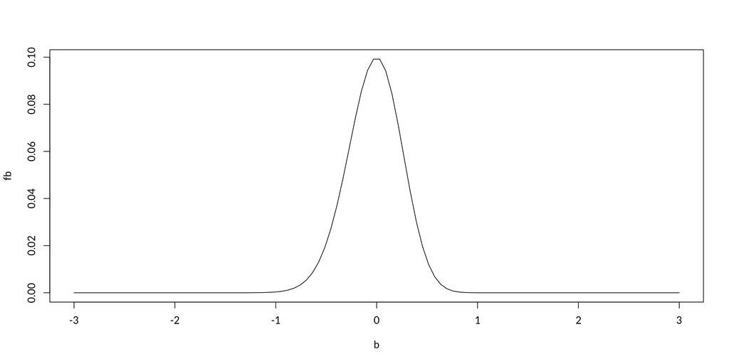

```r
b = seq(-3,3, l = 100)
fb <- integrando(b = b, theta = c(log(10), 0.25), y = 10)
plot(fb ~ b, type = "l")
```

Podemos tentar resolver a integral numericamente para um dado vetor de parâmetros e um valor observado de $y$. Note que para a integração via aproximação de Laplace o integrando tem que ser passado em escala log. Para conferir nossas implementações, vamos também resolver a integral usando a função **integrate()** do **R**.

```r
theta = c(log(10), 0.25)
y = 10

# Gauss-Hermite
gauss_hermite(integrando = integrando, n.pontos = 100,
        theta = theta, y = y)
# [1] 0.06695328

# Laplace
laplace(funcao = integrando, otimizador = "BFGS", n.dim = 1,
        theta = theta, y = y, log = TRUE)
# [1] 0.06687412
# attr(,"logarithm")
# [1] TRUE

# Monte Carlo
monte.carlo(funcao = integrando, n.pontos = 10000, theta = theta,
            y = y, log = FALSE)
# [1] 0.06707815

# Nativa do R
integrate(f = integrando, lower = -Inf, upper = Inf, theta = theta, y = y)
# 0.06695328 with absolute error < 4.4e-06
```

## 2.2 Número de pontos de integração

Uma pergunta natural em termos práticos é quantos pontos de integração utilizar nos algoritmos de Gauss-Hermite e Monte Carlo. Essa pergunta é extremamente relevante, porém não existe uma resposta que funcione em todos os casos. O número de pontos necessários vai depender do modelo e também dos valores dos parâmetros e das observações. Uma estratégia comum é avaliar a integral para um número crescente de pontos de integração e verificar quando o valor estabiliza. Veja o código abaixo

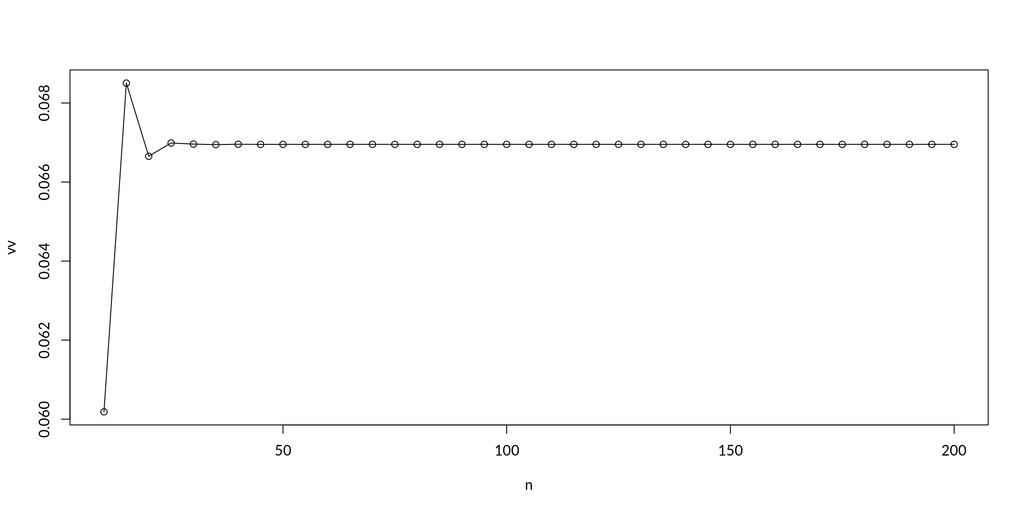

```r
n = seq(10, 200, by = 5)
vv <- c()
for(i in 1:length(n)) {
  vv[i] <- gauss_hermite(integrando = integrando, n.pontos = n[i],
                         theta = theta, y = y)
}
plot(vv ~ n, type = "o")
```

Pelo gráfico parece claro que após 20 pontos de integração o valor da integral estabilizou. Então este seria um valor razoável, ao menos para esta configuração de parâmetros e valor observado.

Um procedimento similar pode ser usado para definir o número de simulações Monte Carlo necessário para aproximar a integral.

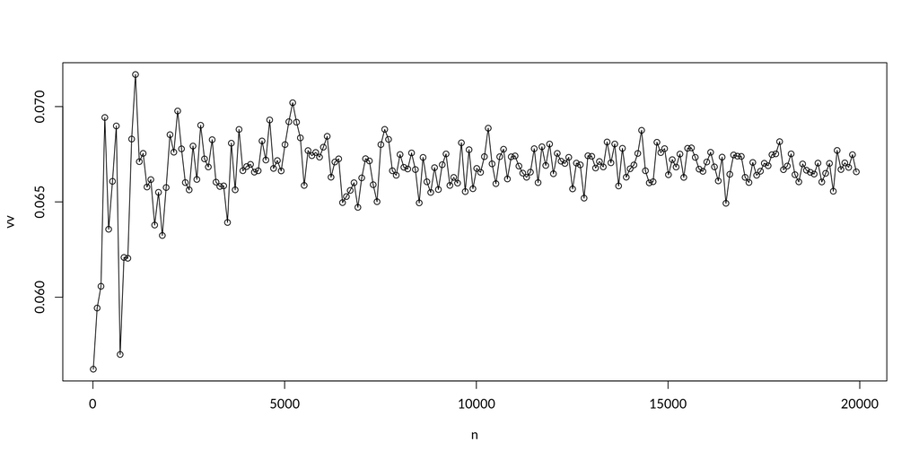

```r
n = seq(10, 20000, by = 100)
vv <- c()
for(i in 1:length(n)) {
  vv[i] <- monte.carlo(funcao = integrando, n.pontos = n[i],
                         theta = theta, y = y)
}
plot(vv ~ n, type = "o")
```

Fica claro na Figura acima que um número muito maior de avaliações da função é necessário no método de Monte Carlo. Além disso, mesmo com 20000 simulações o valor da integral ainda sofre pequenas variações.

Finalmente podemos escrever uma função para avaliar a distribuição marginal de $Y$ usando algum dos nossos algoritmos numéricos.

```r
dpois_gauss <- function(y, theta, method, n_points = NULL) {
  if(method == "GH") {
    out <- gauss_hermite(integrando = integrando, n.pontos = n_points,
                         theta = theta, y = y)
  }
  if(method == "LAPLACE") {
    out <- laplace(funcao = integrando, otimizador = "BFGS", n.dim = 1,
                   theta = theta, y = y, log = TRUE)
  }
  if(method == "Monte Carlo") {
   out <- monte.carlo(funcao = integrando, n.pontos = n_points,
                      theta = theta, y = y)
  }
  if(method == "integrate") {
    out <- integrate(f = integrando, lower = -Inf, upper = Inf,
                     theta = theta, y = y)
  }
  return(out)
}
```

Podemos fazer uma gráfico desta distribuição ma,rginal para alguns valores de $\alpha$ e $\sigma^2$.

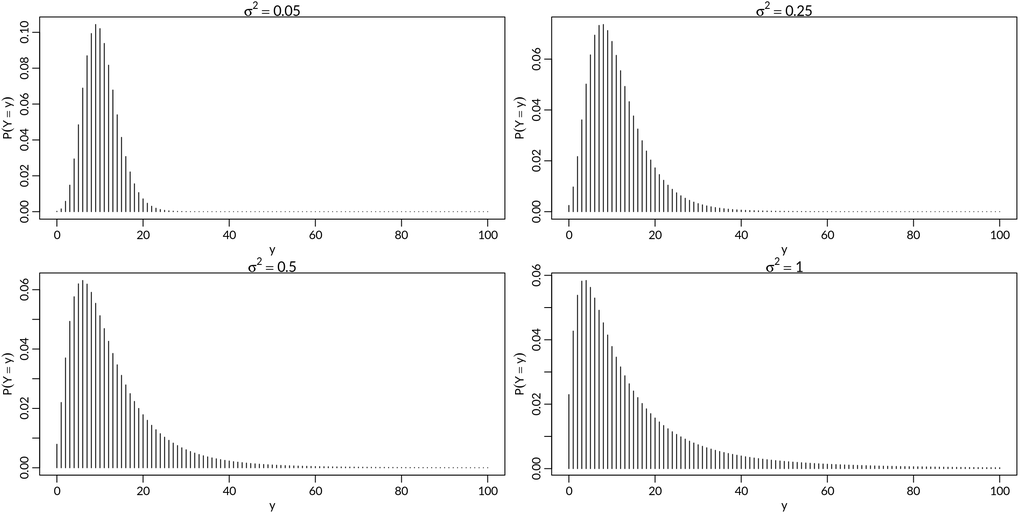

```r
y_grid <- 0:100
dd1 <- c()
dd2 <- c()
dd3 <- c()
dd4 <- c()
for(i in 1:length(y_grid)) {
  dd1[i] <- dpois_gauss(y = y_grid[i], theta = c(log(10), 0.05),
                       method = "GH", n_points = 100)
  dd2[i] <- dpois_gauss(y = y_grid[i], theta = c(log(10), 0.25),
                       method = "GH", n_points = 100)
  dd3[i] <- dpois_gauss(y = y_grid[i], theta = c(log(10), 0.5),
                       method = "GH", n_points = 100)
  dd4[i] <- dpois_gauss(y = y_grid[i], theta = c(log(10), 1),
                       method = "GH", n_points = 100)
}
par(mfrow = c(2,2), mar=c(2.6, 2.8, 1.2, 0.5), mgp = c(1.6, 0.6, 0))
plot(dd1 ~ y_grid, ylab = expression(P(Y == y)), xlab = "y",
     type = "h", main = expression(sigma^2 == 0.05))
plot(dd2 ~ y_grid, ylab = expression(P(Y == y)), xlab = "y",
     type = "h", main = expression(sigma^2 == 0.25))
plot(dd3 ~ y_grid, ylab = expression(P(Y == y)), xlab = "y",
     type = "h", main = expression(sigma^2 == 0.50))
plot(dd4 ~ y_grid, ylab = expression(P(Y == y)), xlab = "y",
     type = "h", main = expression(sigma^2 == 1))
```

Conforme gostaríamos o novo parâmetro $\sigma^2$ controla a variabilidade da nova distribuição, e portanto temos um modelo em que a variância é maior do que a média.

# 3 Simulando do modelo

Uma vez que especificamos o modelo completamente a simulação de observações do modelo é trival, conforme mostra o código abaixo.

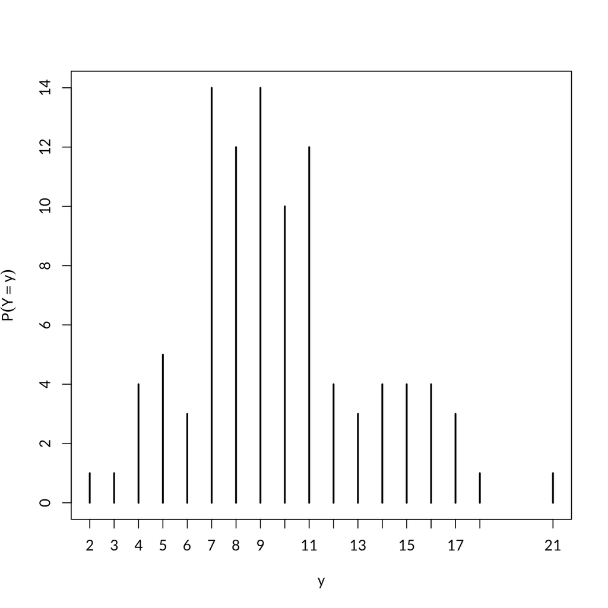

```r
set.seed(123)
n = 100
b <- rnorm(n, mean = 0, sd = 0.25^2)
lambda <- exp(log(10) + b)
y <- rpois(n, lambda = lambda)
plot(table(y), ylab = expression(P(Y == y)), xlab = "y")
```

# 4 Estimação e Inferência

Dado um conjunto de $n$ observações do modelo, podemos estimar os parâmetros $\alpha$ e $\sigma^2$ pelo método de máxima verossimilhança. Assumindo observações independentes a função de log-verossimilhança é simplesmente a soma do log das distribuições marginais vista como uma função dos parâmetros, ou seja,

```r
ll <- function(theta, y, method = "GH", n_points = 100) {
  out <- c()
  for(i in 1:length(y)) {
    out[i] <- log(dpois_gauss(y = y[i], theta = theta,
                       method = method, n_points = n_points))
  }
  return(sum(out))
}
```

Avaliando a verossimilhança em alguns pontos para verificar a implementação.

```r
ll(theta = c(log(10), 0.25), y = y)
# [1] -285.1257
ll(theta = c(log(10), 0.05), y = y)
# [1] -268.7464
ll(theta = c(log(10), 0.0001), y = y)
# [1] -6119.546
```

O próximo passo consiste em maximizar a função de log-verossimilhança. Para isto vamos usar o algoritmo de Newton. Em sala foi fornecido o algoritmo Newton, aqui faremos algumas adaptações para que possamos usar os parâmetros extra da função de log-verossimilhança que controlam o algoritmo que resolve a integral dentro da verossimilhança.

```r
newton <- function(fx, jacobian, x1, tol = 1e-04, max_iter = 10, ...) {
  solucao <- matrix(NA, ncol = length(x1), nrow = max_iter)
  solucao[1,] <- x1
  for(i in 1:max_iter) {
    J <- jacobian(solucao[i,], ...)
    #J <- IO(solucao[i,], y = y)
    grad <- as.numeric(fx(solucao[i,], ...))
    #grad <- as.numeric(fx(solucao[i,], y = y))
    solucao[i+1,] = solucao[i,] - solve(J, grad)
    print(solucao[i+1,])
    if( sum(abs(solucao[i+1,] - solucao[i,])) < tol) break
    }
  return(solucao)
}
```

O algoritmo de Newton exige o cálculo da primeira e segunda derivada da função objetivo. Note que neste caso tais derivadas são impossíveis de serem obtidas, uma vez que a função de log-verossimilhança é dada por uma integral que não tem solução analitica. Sendo assim, vamos usar os métodos numéricos que vimos em sala para obter uma aproximação para a primeira e a segunda derivada da função de log-verossimilhança. Para facilitar vamos usar as funções do pacote **rootSolve**.

```r
## Função escore
fx <- function(theta, y, method = "GH", n_points = 100) {
  out <- gradient(f = ll, x = theta, y = y, method = method, n_points = n_points)
  return(out)
}

## Negativo da Informação observada
IO <- function(theta, y, method = "GH", n_points = 100) {
  out <- pracma::hessian(f = ll, x0 = theta, y = y,
                            method = method, n_points = n_points)
  return(out)
}
```

Resolvendo o sistema não-linear usando o método de Newton

```r
require(rootSolve)
# Loading required package: rootSolve
#
# Attaching package: 'rootSolve'
# The following objects are masked from 'package:pracma':
#
#     gradient, hessian
require(pracma)
fit <- newton(fx = fx, jacobian = IO, x1 = c(log(10), 0.25^2),
              y = y, max_iter = 10)
# [1] 2.248236089 0.009089622
# [1] 2.26898613 0.01149581
# [1] 2.26797562 0.01410513
# [1] 2.26657829 0.01708982
# [1] 2.26460873 0.02097707
# [1] 2.26159655 0.02688336
# [1] 2.25861808 0.03298173
# [1] 2.25802022 0.03436426
# [1] 2.25800670 0.03440058
# Solução
fit[dim(na.exclude(fit))[1],]
# [1] 2.25800670 0.03440058
```

Usando a distribuição assintótica do MLE, podemos facilmente calcular intervalos de confiança.

```r
Est <- fit[dim(na.exclude(fit))[1],]
I0_obs <- IO(theta = Est, y = y)
VarCov <- solve(-I0_obs)
Var <- sqrt(diag(VarCov))
data.frame("Estimates" =  Est, "Std.Error" = Var,
           "Z-value" = Est/Var)
#    Estimates  Std.Error   Z.value
# 1 2.25800670 0.03817094 59.155122
# 2 0.03440058 0.01905075  1.805734
```

[output not shown]